# 571-note

## 571 Quiz 1

### Lecture 5

### 1. explain `handle_unknown="ignore"` hyperparameter of scikit-learn's `OneHotEncoder`;

- During cross-validation, when there are unknown categories in the test split or training split due to small number of instances, the default behaviour of `OneHotEncoder` is throwing an error.
- Specify `handle_unknown="ignore"` in `OneHotEncoder`
  - All unknown categories will be represented with all zeros.

```
numeric_transformer = make_pipeline(SimpleImputer(strategy="median"), StandardScaler())

categorical_transformer = make_pipeline(
    SimpleImputer(strategy="constant", fill_value="missing"),
    OneHotEncoder(handle_unknown="ignore"),
)

preprocessor = ColumnTransformer(
    transformers=[
        ("num", numeric_transformer, numeric_features),
        ("cat", categorical_transformer, categorical_features),
    ]
)
pipe = make_pipeline(preprocessor, SVC())
```

### 2. identify when it's appropriate to apply ordinal encoding vs one-hot encoding;

- When a categorical column has an order in the values, you can use `OrdinalEncoder`
  - Default: encode the categories by alphabetical order
- You can specify the order that you want
- For the binary feature, use `OneHotEncoder`

```
# Create an order of the education level column
education_levels = ['Preschool', '1st-4th', '5th-6th', '7th-8th',
                    '9th', '10th', '11th', '12th', 'HS-grad',
                    'Prof-school', 'Assoc-voc', 'Assoc-acdm',
                    'Some-college', 'Bachelors', 'Masters', 'Doctorate']

# Create an OE instance
oe = OrdinalEncoder(categories=[education_levels], dtype=int)
oe.fit(X_train[["education"]])
ed_transformed = oe.transform(X_train[["education"]])
ed_transformed = pd.DataFrame(data=ed_transformed, columns=["education_enc"], index=X_train.index)
oe.categories_

# Identify column features
numeric_features = ['age', 'fnlwgt', 'capital.gain',
                    'capital.loss', 'hours.per.week']
categorical_features = ['workclass', 'marital.status', 'occupation',
                        'relationship', 'race', 'sex', 'native.country']
ordinal_features = ['education']
target_column = 'income'

# Construct appropriate transformers
numeric_transformer = make_pipeline(SimpleImputer(strategy="median"), StandardScaler())

categorical_transformer = make_pipeline(
    SimpleImputer(strategy="constant", fill_value="missing"),
    OneHotEncoder(handle_unknown="ignore"),
)

ordinal_transformer = make_pipeline(
    SimpleImputer(strategy="constant", fill_value="missing"),
    OrdinalEncoder(categories=[education_levels], dtype=int,),

)

# Apply each transformer to each feature with ColumnTransformer
preprocessor = ColumnTransformer(
    transformers=[
        ("num", numeric_transformer, numeric_features),
        ("cat", categorical_transformer, categorical_features),
        ("ordinal", ordinal_transformer, ordinal_features)
    ]
)

# Make a pipeline
pipe = make_pipeline(preprocessor, SVC())

# Score
scores = cross_validate(pipe, X_train, y_train, return_train_score=True)
```

### 3. explain strategies to deal with categorical variables with too many categories;

- It is better to group the categories into bigger categories
- Or have "other" category for rare cases
- If a certain feature is not necessary for prediction, just exclude it

### 4. explain why text data needs a different treatment than categorical variables;

- With BOW (Bag of words) representation, each word becomes a feature.
  - Two components:
  - the vocabulary (all unique words in all documents)
  - a value indicating either the presence or absence or the count of each word in the document.
- In this case, carrying out OHE doesn't make sense because there are no fixed categories in the text messages, and each word is going to be different and unique. So, free text column should be encoded with CountVectorizer.

### 5. use scikit-learn's CountVectorizer to encode text data;

- `CountVectorizer`
  - Converts a collection of text documents to a **sparse matrix** of word counts.
  - Each row represents a "document" (e.g., a text message in our example).
  - Each column represents a word in the vocabulary in the training data.
  - Each cell represents how often the word occurs in the document.
  - `CountVectorizer` converts words to lowercase, and get rid of punctuation and special characters.
- Sparse matrices
  - Most words do not appear in a given document.
  - We get massive computational savings if we only store the nonzero elements.
  - There is a bit of overhead, because we also need to store the locations: e.g. "location (3,31): 1".
  - However, if the fraction of nonzero is small, this is a huge win.

```
# Raw text data
X = [
    "URGENT!! As a valued network customer you have been selected to receive a £900 prize reward!",
    "Lol you are always so convincing.",
    "Nah I don't think he goes to usf, he lives around here though",
    "URGENT! You have won a 1 week FREE membership in our £100000 prize Jackpot!",
    "Had your mobile 11 months or more? U R entitled to Update to the latest colour mobiles with camera for Free! Call The Mobile Update Co FREE on 08002986030",
    "As per your request 'Melle Melle (Oru Minnaminunginte Nurungu Vettam)' has been set as your callertune for all Callers. Press *9 to copy your friends Callertune",
]
y = ["spam", "non spam", "non spam", "spam", "spam", "non spam"]


# Vectorizer
vec = CountVectorizer()
X_counts = vec.fit_transform(X)

# Convert the bow representation to dataframe
bow_df = pd.DataFrame(X_counts.toarray(), columns=sorted(vec.vocabulary_), index=X)
bow_df
```

- `OneHotEncoder` and sparse features
  - By default, `OneHotEncoder` also creates sparse features.
  - You could set sparse=False to get a regular numpy array.
  - If there are a huge number of categories, it may be beneficial to keep them sparse.
  - For smaller number of categories, it doesn't matter much.

### 6. explain different hyperparameters of CountVectorizer.

| Hyperparameter | Description |
| --- | --- |
| binary | whether to use absence/presence feature values or counts |
| max_features | only consider top `max_features` ordered by frequency in the corpus |
| max_df | ignore features which occur in more than `max_df` documents |
| min_df | ignore features which occur in less than `min_df` documents |
| ngram_range | consider word sequences in the given range |

- `max_features`: control the number of features to consider.
- `max_df = 25` means "ignore terms that appear in more than 25 documents.

```
vec8_binary = CountVectorizer(binary=True, max_features=8)     # only counts absence/presence, for the top 8 features.
X_counts = vec8_binary.fit_transform(X)
```

```
# preprocessing with countvectorizer
pipe = make_pipeline(CountVectorizer(), SVC())
pipe.fit(X, y)
pipe.predict(X)
pipe.score(X, y)
```

### Lecture 6

### 1. explain the need for hyperparameter optimization

- There are a lot of hyperparameters
- Picking reasonable hyperparameters is important because if we don't do it, we might end up with an underfit or overfit model.
- Some ways to pick hyperparameters:
  - Expert knowledge or heuristics
  - Systematic / automated optimization

**Automated hyperparameter tuning**

- Advantage
  - Reduce human effort
  - Less prone to error and improve reproducibility
  - Data-driven approaches may be effective
- Disadvantage
  - May be hard to incorporate intuition
  - Be careful about overfitting on the validation set

### 2. carry out hyperparameter optimization using sklearn's GridSearchCV and RandomizedSearchCV

#### 2.1. Exhausitive grid search `GridSearchCV`

- A user specifies a set of values for each hyperparameter
- The method considers product of the sets and then evaluates each combination one by one.

```
from sklearn.model_selection import GridSearchCV
param_grid = {
    "svc__gamma": [0.1, 1.0, 10, 100],
    "svc__C": [0.1, 1.0, 10, 100],
}

grid_search = GridSearchCV(pipe, param_grid, cv=5, n_jobs=-1, return_train_score=True)
grid_search.fit(X_train, y_train);
```

- `grid_search.best_score_` : returns the best score
- `grid_search.best_params_` : returns the best hyperparameters
- `__` syntax
  - We can access the parameters of the inner objects by using `__` to go deeper.
  - `svc__gamma` : the `gamma` of the `svc` of `pipe`

```
# access to a hyperparameter of a transformer in `ColumnTransformer()`
param_grid = {
    "svc__gamma": [0.1, 1.0],
    "columntransformer__num__simpleimputer__strategy": ['mean', 'median'],
}

grid_search = GridSearchCV(pipe, param_grid, cv=5, n_jobs=-1, return_train_score=True);
grid_search.fit(X_train, y_train);
```

##### Problems with exhaustive grid search

- Required number of models to evaluate grows exponentially with the dimensionally of the configuration space.
- Example) If we have **5 hyperparameters, 10 different values** for each hyperparameter
  - You'll be evaluating $10^5=100,000$ models! That is you'll be calling cross_validate 100,000 times!

#### 2.2. Randomized hyperparameter optimization `RandomizedSearchCV`

- Randomly searches hyperparameters based on the given budget.
- Weighs on important features

```
# random search with the grid of size 144
from sklearn.model_selection import RandomizedSearchCV
param_grid = {
    "svc__gamma": 10.0 ** np.arange(-6, 6),
    "svc__C": 10.0 ** np.arange(-6, 6)
}


random_search = RandomizedSearchCV(pipe, param_distributions=param_grid, n_jobs=-1, n_iter=10, cv=5);
random_search.fit(X_train, y_train);
```

##### Advantages of `RandomizedSearchCV`

- Faster compared to `GridSearchCV`
- Adding parameters that do not influence the performance does not affect efficiency.
- Especially works better when some parameters are more important than others

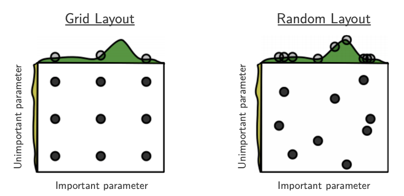

### 3. explain optimization bias

- If our dataset is small and if the validation set is hit too many times, we suffer from optimization bias or overfitting the validation set.
1. Optimization bias of parameter learning:
- During learning, we could search over tons of different decision trees.
- So we can get "lucky" and find one with low training error by chance.
  - "Overfitting of the training error".
1. Optimization bias of hyper-parameter learning:
- Here, we might optimize the validation error over 100 values of max_depth.
- One of the 100 trees might have low validation error by chance.

### 4. identify and reason when to trust and not trust reported accuracies

- When our training data is small, our validation splits in cv would be also small. Therefore, it is hard to believe the results of the cv score and the best hyperparameter. (Optimization bias)
  - It is possible that we got lucky on the validation set to get the least validation error.
  - We cannot trust the cv scores and the cv's ability to choose of the best hyperparameters.
- Large datasets solve many of these problems
  - With infinite amounts of training data, overfitting would not be a problem and you could have your test score = your train score.
  - Overfitting happens because you only see a bit of data and you learn patterns that are overly specific to your sample.
- What to do if your test score is much lower than your cross-validation score:
  - Try simpler models and use the test set a couple of times - it's not the end of the world.
  - Communicate this clearly when you report the results.

### Lecture 7

### 1. Explain the naive assumption of naive Bayes.

#### 1.1. Naive Bayes

- Probabilistic classifier
- "Learning" as a problem of statistical inference.
- Way faster than SVC classifier

```
from sklearn.naive_bayes import MultinomialNB

pipe_nb = make_pipeline(CountVectorizer(), MultinomialNB())
scores = cross_validate(pipe_nb, X_train, y_train, return_train_score=True)
store_cross_val_results('Naive Bayes', scores, results_dict)
```

#### 1.2. The naive assumption of naive Bayes

- Naive Bayes classifier assumes that the effect of the value of a predictor on a given class is **independent** of the values of other predictors.

### 2. Predict targets by hand on toy examples using naive Bayes.

#### 2.1. Naive Bayes prediction idea

- Naive Bayes calculates the following probability scores.
  - $P(\text{spam} \mid \text{block} = 0, \text{free} = 1, \text{prize} = 0, \text{urgent=1})$
  - $P(\text{non spam} \mid \text{block} = 0, \text{free} = 1, \text{prize} = 0, \text{urgent=1})$
- Picks the label with **higher probability scores**.

#### 2.2. Applying Bayes' theorem

- Uses Bayes' theorem to calculate probabilities:
- Bayes' theorem $$P(A \mid B) = \frac{P(B \mid A) \times P(A)}{P(B)}$$
- Apply to the examples above $$P(\text{spam} \mid \text{message})= \frac{P(\text{block} = 0, \text{free} = 1, \text{prize} = 0, \text{urgent} = 1 \mid \text{spam}) \times P(\text{spam})}{P(\text{block} = 0, \text{free} = 1, \text{prize} = 0, \text{urgent=1})}$$

$$P(\text{non spam} \mid \text{message}) = \frac{P(\text{block} = 0, \text{free} = 1, \text{prize} = 0, \text{urgent} = 1 \mid \text{non spam}) \times P( \text{non spam})}{P(\text{block} = 0, \text{free} = 1, \text{prize} = 0, \text{urgent=1})}$$

- $P(\text{message})$: marginal probability that a message has the given set of words
  - Hard to calculate but can be ignored in our scenario as it occurs in the denominator for both $P(\text{spam} \mid \text{message})$ and $P(\text{non spam} \mid \text{message})$.
  - So we **ignore the denominator** in both cases.

$$P(\text{spam} \mid \text{message}) \propto P(\text{block} = 0, \text{free} = 1, \text{prize} = 0, \text{urgent} = 1 \mid \text{spam}) \times P(\text{spam})$$

#### 2.3. Applying naive Bayes' assumption

- Features are independent, conditioned on the target.

$$\begin{equation} \begin{split}P(\text{block} = 0, \text{free} = 1, \text{prize} = 0, \text{urgent} = 1 \mid \text{spam}) \approx P(\text{block} = 0 \mid \text{spam}) \times P(\text{free} = 1 \mid \text{spam}) \times P(\text{prize} = 0 \mid \text{spam}) \times P(\text{urgent} = 1 \mid \text{spam}) \end{split} \end{equation}$$

#### 2.4. Calculating $P(\text{spam} \mid \text{message})$

- We need prior probability $P(spam)$
  - Marginal probability that a message is spam
- We need conditional probabilities
  - $P(\text{block} = 0 \mid \text{spam})$
  - $P(\text{free} = 1 \mid \text{spam})$
  - $P(\text{prize} = 0 \mid \text{spam})$
  - $P(\text{urgent} = 1 \mid \text{spam})$

= P(block=0 | spam) *P(free=1 | spam)* P(prize=0 | spam) *P(urgent=1 | spam)* P(spam)

### 3. Use scikit-learn's MultiNomialNB, BernoulliNB, and GaussianNB.

1. MultiNomialNB
- Categorical features (discrete)
1. GaussianNB
- Continuous features
- Assume each feature is normally distributed
- Calculate the mean ($\mu_k$) and standard deviation ($\sigma_k$) for each feature for each class
- Use `PowerTransformer` to transform our data to try and make it more normal

```
from sklearn.preprocessing import PowerTransformer

pt = PowerTransformer(method='yeo-johnson')
X_train[['longitude', 'latitude']] = pt.fit_transform(X_train)
```

### 4. Use `predict_proba` for different classifiers and explain its usefulness.

```
pipe_nb_toy.predict_proba(deploy_test)

>>> array([[0.23584906, 0.76415094]])
```

- Naive Bayes classifier gives you probability estimates for each class
- The classifier above is 76% confident that the class is spam.
- This can help us understand the model.
- Although decision tree, kNN, and RBF SVM are not set in a probabilistic framework, they still have predict_proba method to get the probability estimates.
  - `DecisionTreeClasifier.predict_proba`: Computed as fraction of that class in leaf node.
  - `KNeighborsClassifier.predict_proba`: Computed as fraction of that class in $k$ neighbours.
  - `MultinomialNB.predict_proba`: Already computed, just need to normalize them (so they sum to 1).
- **Why don't `predict_proba` scores match with the probability scores we calculated before?**
  - The scores we computed are not normalized. Remember that we ignored the denominator.
  - The scores of `predict_proba` are normalized so that they sum to 1.
  - The model is using something called "smoothing" to avoid the problem of zero probabilities.

### 5. Explain the need of smoothing in naive Bayes.

- When naive Bayes calculates probabilities, zero probabilities might happen.
  - Naive Bayes naively multiplies all the feature likelihoods together
  - and if any of the terms is zero, it's going to void all other evidence and the probability of the class is going to be zero.

#### 5.1. Solution: Laplace smoothing

- The simplest way to avoid zero probabilities is to add one to all the counts.
- All the counts that used to be zero will now have a count of 1, the counts of 1 will be 2, and so on.
- In scikit-learn we control it using hyperparameter `alpha` (by default alpha=1.0).

#### 5.2. Adjusting the counts with `alpha`

```
pipe_nb = make_pipeline(CountVectorizer(), MultinomialNB(alpha=1.0))
pipe_nb.fit(X_train, y_train)
```

### 6. Explain how alpha controls the fundamental tradeoff.

- As the value of `alpha` decreases, the gap between train score and the validation score will increase.
- As the value of `alpha` increases, both train score and validation score will not be that good.
  - High alpha : underfitting  
    we are adding large counts to everything and so we are diluting the data
  - Low alpha : overfitting

### 7. Use naive Bayes for multi-class classification.

```
pipe_multi = make_pipeline(CountVectorizer(), MultinomialNB())
scores = cross_validate(pipe_multi, X_news_train, y_news_train, return_train_score=True)
pipe_multi.fit(X_news_train, y_news_train);
pipe_multi.predict_proba([X_news_test[100]])

>>>
array([[7.26904475e-19, 1.48743104e-10, 4.16538604e-28, 2.96340768e-10,
        1.91391647e-14, 1.00000000e+00, 4.34194388e-28, 2.40916532e-18,
        9.74009600e-22, 1.72603033e-31, 5.61184330e-31, 8.76853929e-14,
        1.00705690e-16, 2.70331089e-13, 2.36762710e-21, 5.91222397e-16,
        3.61589511e-15, 1.49715839e-13, 2.92789387e-16, 1.20413840e-24]])
```

- Naive Bayes is a **generative model** because it's modeling the **joint distribution over the features $X$ and labels $y$**.
- In the next lecture, we'll look at a **discriminative model**, which models $P(y\mid X)$ rather than $P(X,y)$.

### 8. Name advantages and disadvantages of naive Bayes.

#### 8.1. Advantages

- Surprising accuracy
- A fast and robust way to learn the corresponding parameters
- Scales great; learning a naive Bayes classifier is just a matter of counting how many times each attribute co-occurs with each class
- Can be easily used for multi-class classification.
- It's closely related to linear classifiers we'll see in the next lecture.
- Can provides a informative set of features from which to predict the class (next class)

#### 8.2. Disadvantages

- Assumes that spammers generate e-mails by picking words at **random**. It means that sentences have no syntax and content. Is that a fair assumption?
  - Due to naive assumptions: all features are independent.
  - oversimplification
  - sometimes the best theories are the most oversimplified, provided their predictions are accurate, because they explain the most with the least.
- Although naive Bayes is known as a decent classifier, it is known to be a **bad estimator**, so the probability outputs from predict_proba are not to be taken too seriously.

### Lecture 8

### 1. Explain the general intuition behind linear models

### 2. Explain the predict paradigm of linear models

#### 1.1. Intuition behind a linear classifier

- Learn **coefficients (weights)** associated with features
- Use these learned coefficients to make predictions. For example, consider the following review $x_i$.

  > It got a bit boring at times but the direction was excellent and the acting was flawless.
- Feature vector for $x_i$: [1, 0, 1, 1, 0, 0, 0]
- $score(x_i) = $ coefficient(boring) $\times 1$ + coefficient(excellent) $\times 1$ + coefficient(flawless) $\times 1$ = $-1.40 + 1.93 + 1.43 = 1.96 > 0$, so predict the review as positive 👍.

#### 1.2. A linear classifier

- A linear function of $X$ followed by a threshold.
- $w$ : weight
- $b$ : bias

$$ \begin{split} z = w_1x_1 + \dots + w_dx_d + b\\ = w^Tx + b \end{split} $$$$\hat{y} = \begin{cases} 1, \text{if } z \geq r\\ -1, \text{if } z < r \end{cases}$$

- Components of a linear classifier:
  - input features ($x_1, \dots, x_d$)
  - coefficients (weights) ($w_1, \dots, w_d$)
  - bias ($b$ or $w_0$) (can be used to offset your hyperplane)
  - threshold ($r$)
- In our example, we assumed $r=0$ and $b=0$.
- You can think of the coefficients as controlling the **orientation/tilt of the hyperplane**
- the bias representing the **intercept** (offset from the origin). (More on this in 573.)

### 3. Use scikit-learn's LogisticRegression classifier

- Use fit, predict, predict_proba
- Use coef_ to interpret the model weights

#### 3.1. Logistic regression

- A linear model for classification
- It learns weights associated with each feature and the bias
- The decision boundary is a hyperplane dividing the feature space in half.

```
lr = LogisticRegression()
scores = cross_validate(lr, X_train, y_train, return_train_score=True)
pd.DataFrame(scores)
```

#### 3.2. Decision boundaries

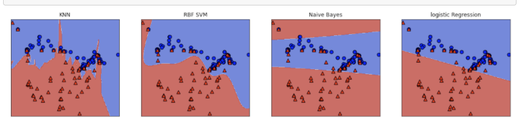

#### 3.3. Use `coef_` to interpret the model weights

```
lr = LogisticRegression()
lr.fit(X_train, y_train)
print("Model weights: %s"%(lr.coef_)) # these are weights
print("Model intercept: %s"%(lr.intercept_)) # this is the bias term
data = {'features': X_train.columns, 'coefficients':lr.coef_[0]}
pd.DataFrame(data)

>>> Model weights: [[-0.04108149 -0.33683126]]
Model intercept: [10.8869838]
```

#### 3.4. Prediction with learned weights

- For example, our examples are [-64.8001, 46.098], have weights [[-0.04108149 -0.33683126]] and bias [10.8869838].
- Then we can calculate $\hat{y} = \text{np.dot}(w, x) + b$
  - np.dot([-64.8001, 46.098], [-0.04108149 -0.33683126]) + [10.8869838]

    > `array([-1.97817876])`
- Our threshold here is `0`. So the predict class is `-1`
- **Hard predictions**: If positive, predict $+1$; if negative, predict $-1$.

#### 3.5. Soft predictions with the sigmoid function

- You can also have "soft predictions", aka `predicted probabilities`.
- To convert the raw model output into probabilities, instead of taking the sign, we apply the sigmoid.

$$\frac{1}{1+e^{-x}}$$

- The threshold $w^Tx=0$ corresponds to $p=0.5$.
- In other words, if our **predicted probability is above $0.5$ then our hard prediction is $+1$**.

#### 3.6. Soft predictions with `predict_proba`

- You can get the probabilities (confidence) of the classifier's prediction using the model.predict_proba method. (Similar to naive Bayes!)

```
lr.predict_proba([example])
>>> array([[0.87848688, 0.12151312]])
```

- The result is the same as the result of `sigmoid(the np.dot(w,x) +b)`

#### 3.7. Find the example where the model is the most confident

```
# Build a pipeline with LogisticRegression
pipe_lr = make_pipeline(CountVectorizer(stop_words='english'),
                        LogisticRegression()) # pipeline with logistic regression

# Fit and get the prediction probability
pipe_lr.fit(X_train, y_train);
pipe_lr.predict_proba(X_train)
spam_probs = pipe_lr.predict_proba(X_train)[:, 1] # only get probabilities associated with spam class

# Find the most spam-like message
most_spammy = np.argmax(spam_probs)
print("MESSAGE: %s\n" %(X_train.iloc[[most_spammy]]))
print("True target: %s\n" %(y_train.iloc[most_spammy]))
print("Predicted target: %s\n" %(pipe_lr.predict(X_train.iloc[[most_spammy]])[0]))
print("Prediction probability: %0.4f" %(spam_probs[most_spammy]))
```

#### 3.8. Interpretability of linear classifiers

- We can get the most useful feature for prediction with a coefficient:
  - In linear models, the $j^{th}$ coefficient tells us how feature $j$ affects the prediction. (`coef_` - LinearRegression object)
  - The vocabulary can be obtained using `get_feature_names()` - CountVectorizer object
- The features which have coefficient with bigger magnitudes might be useful for prediction

```
weights = pipe_lr.named_steps['logisticregression'].coef_.flatten()
vocab = pipe_lr.named_steps['countvectorizer'].get_feature_names()
```

- In linear models:
  - the $j$th coefficient tells us how feature $j$ affects the prediction
  - if $w_j > 0$ then increasing $x_{ij}$ moves us toward predicting $+1$
  - if $w_j < 0$ then increasing $x_{ij}$ moves us toward prediction $-1$
  - if $w_j == 0$ then the feature is not used in making a prediction

### 4. Compare logistic regression with naive Bayes

- Naive Bayes has overly strong conditional independence assumptions. So it is not great when **features are correlated**.
  - If two features are strongly correlated, naive Bayes will be overestimating the evidence of that feature.
- Logistic regression is much more **robust to correlated features**
  - If two features are correlated, regression will assign part of the weight to one and part to another.

### 5. Explain the advantages and limitations of linear classifiers

#### 5.1. Linear SVM

- SVM with linear kernel

```
models = {
    "RBF SVM": SVC(gamma=0.01), # default SVM is RBF SVM
    "Linear SVM": SVC(kernel='linear')
}
```

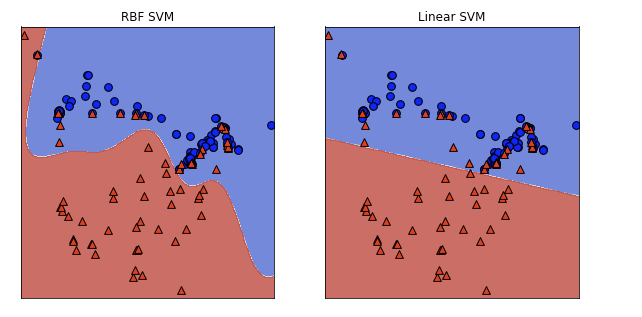

- You can get weights using `coef_` and bias using `intercept_` like `LogisticRegression`.

#### 5.2. Limitation of linear classifiers

- Is your data "linearly separable"? Can you draw a hyperplane between these datapoints that separates them with 0 error.
  - If the training examples can be separated by a linear decision rule, they are linearly separable.
- There are a lot of real-life data that are not linearly separable.

### 6. Carry out multi-class classification using OVR and OVO strategies.

- Logistic regression works well with multi-class classification problems.
- However, if you need to work with classifiers that are only applicable to binary problems: use `OVR` and `OVO` strategies.

#### 6.1. One-vs-rest

- Turns $k$-class classification into $k$ binary classification problems
- Builds $k$ binary classifiers; for each classifier, the class is fitted against all the other classes
- Each one gives a probability of that class assuming it to be "positive" using the sigmoid function
- Normalize these values across all the classes
- The class with the maximum value is the prediction
- You can do this yourself for any binary classifier using the meta-classifier OneVsRestClassifier

```
from sklearn.multiclass import OneVsRestClassifier, OneVsOneClassifier
ovr = OneVsRestClassifier(LogisticRegression())
ovr.fit(X_train, y_train)
plot_classifier(X_train, y_train, ovr)
```

#### 6.2. One-vs-one

- A multi-class `linear SVM` looks similar, though, by default, it's done with "one-vs-one" instead of one-vs-rest
- This requires fitting $O(k^2)$ classifiers, where $k$ is number of classes, which is **slow**.
  - To be precise, it requires fitting $k \times (k − 1)/2$ classifiers;
  - each class gets paired up with all other classes except itself and we divide by 2 because class 1 vs. class 2 classifier is the same as class 2 vs. class 1 classifier.
- Note that `SVC multiclass mode` is implemented using **one-vs-one** scheme whereas `LinearSVC` uses **one-vs-rest** scheme.

```
model = OneVsOneClassifier(SVC())
model.fit(X_train_multi, y_train_multi);
```

#### 6.3. When do we use which?

- Most of the methods you'll use will have native multi-class support.
- However, it's good to know in case you ever need to extend a binary classifier (perhaps one you've implemented on your own).

### Question for discussion

1. handle_unknown="ignore" would treat all unknown categories equally.
- True. All unknown categories will be rows of zeros.
1. Creating groups of rarely occurring categories might overfit the model.
- False. It will reduce the probability of overfitting the model.
1. As you increase the value for `max_features` hyperparameter of CountVectorizer the training score is likely to go up.
   - Varada's answer: True because increasing the value of max_features means we include each and every word from the training data in the dictionary and the training score is likely to go up.
2. If we encounter a word in the validation or the test split that's not available in the training data, we'll get an error.
   - Varada's answer: False because if the word isn't in the dictionary, we would just ignore the word.
3. `max_df` hyperparameter of CountVectorizer can be used to get rid of most frequently occurring words from the dictionary.
   - True because words such as a, the, in, of occur in most of the documents, and with max_df hyperparameter, we can control the features to be used based on the number of documents they occur in. So if we set this to a higher proportion, we can get rid of such stop words.
4. Suppose you have 10 hyperparameters, each with 4 possible values. If you run GridSearchCV with this parameter grid, how many cross-validation experiments it would carry out?
- $4^{10}$ times.
1. GridSearchCV exhaustively searches the grid and so it's guaranteed to give you the optimal hyperparameters for the given problem.
- False. It searches the best hyperparameter based on the grid that you passed in. Therefore, if you passed a small range of grid, it might not miss the "optimal" hyperparameters.
1. It is possible to get different hyperparameters in different runs of RandomizedSearchCV.
- True.
1. Suppose you have 10 hyperparameters and each takes 4 values. If you run RandomizedSearchCV with this parameter grid, how many cross-validation experiments it would carry out?
- It depends on `n_iter` hyperparameter.
1. Would you trust the model?
- You have a dataset and you give me half of it. I build a model using all the data you have given me and I tell you that the model accuracy is 0.99. Would it classify the rest of the data with similar accuracy?
  - Probably not: it might be overfitting the model.
- You have a dataset and you give me half of it. I build a model using 80% of the data given to me and report the accuracy of 0.95 on the remaining 20% of the data. Would it classify the rest of the data with similar accuracy?
  - Probably.
- You have a dataset and you give me half of it. The dataset given to me is rather small and so I split it into 96% train and 4% validation split. I carry out hyperparameter optimization using the 4% validation split and report validation accuracy of 0.97. Would it classify the rest of the data with similar accuracy?
  - Probably not: the size of the validation split is too small.
1. When we ignore the marginal probability P(message) when calculating $P(\text{spam} | \text{message})$ or $P(\text{non spam} | \text{message})$, are these going to be well-defined probabilites? Does it matter?
- No, it is not well-defined probabilities as we ignore the denominators. But it doesn't matter as we just want to compare the probability of being spam given the message and the probability of not being spam given the message.
1. (T/F) Laplace smoothing helps us deal with unknown words, the words that do not occur in the vocabulary of the training set.
- False
- It just helps us deal with the zero-probability problem.
1. Naive Bayes should only be used if the "naive" conditional independence assumption holds for your problem.
- Varada's answer: leaning towards False
1. Naive Bayes should only be used when the features (i.e. X-values) are binary.
- Varada's answer: False.
- You can use naive Bayes for multi-classification problems. It will calculate the probability of being each class, and the class with the highest probability will be selected for prediction.
1. Can logistic regression work with categorical features?
- No, we need numerically encoded features for logistic regression.
1. Is scaling important for logistic regression?
- No, but it is good to do it.
1. Is it possible to identify most important features using $k$-NNs?
- No, because k-NN is an analogy-based model, so it learns based on examples not the features.

17-1. What about decision trees and naive Bayes?

- Yes. In case of decision trees, the parameters that divide the decision in an earlier stage would be considered as the more important features.
- In case of naive Bayes, you can get `featrue_log_prob_` for interpreting the model using `coef_`.
1. The coefficients of a linear classifier have the following interpretation: if coefficient $j$ is large, that means a change in feature $j$ has a large impact on the prediction.
- False for two reasons. First, the interpretation is associated with the **magnitude of the coefficient**. For example, consider coefficients 0.2 and -3. The former is larger then the latter but the latter would have a larger impact on the prediction. Second, it also depends upon **the scale of the feature values**. Suppose you have two features: $x_1$ which is either 0 or 1 and $x_2$, which is either 0 or 1000 and suppose $w_1 = 0.5 > w_2 =0.1$. In this case, $x_2$ would still have a larger impact on the prediction, as it's scale is much larger.
1. For linear classifiers, the decision boundary (the boundary dividing the two classes) is a $d-1$-dimensional hyperplane, where $d$ is the number of features.
- True. For example, in our 2-dimensional cities dataset, the decision boundary is a one-dimensional line.
1. When you have correlated features, logistic regression might be a better choice than naive Bayes.
- True. Naive Bayes assumes **conditional independence of features given the target value** and it's not a particularly thoughtful choice when you have correlated features.
- Logistic regression is **a bit more robust to correlated features** compared to naive Bayes because it can adjust the coefficients for the features so that only one of the correlated features is considered.
1. Feature scaling is a good idea for logistic regression.
- True. It's a good idea to carry out feature scaling for logistic regression for feature interpretation. For instance, suppose you have two features $x_1$ which, is either 0 or 1, and $x_2$, which is either 0 or 1000 and if $w_1$ and $w_2$ are equal, the latter is going to have a bigger impact on the prediction because the feature scale is larger. So with different feature scales, *it's hard to interpret feature importance simply based on the coefficients*. The easiest way to compensate for this is **simply to scale features before training**.
1. Suppose you want to train **one-vs-rest** classifier on a 1000-class problem. Suppose the training time for each binary classifier is $t$. How much time it would take to train the one-vs-rest classifier?
- $1000 \times t$ (correct answer)
- $1000^2 \times t$
- $((1000)(999)/2) \times t$
  - OVO: $\frac{1000*999}{2} \times t$
  - OVR: $1000 \times t$ (turn k-class classification into k binary classification problems)